# Relationship between Color Score and Bleaching Metrics

Serena Hackerott and Lauren Gregory

7/19/2024

# Setup

### Load Packages

```r
##Install Packages if Needed
if (!require("ggplot2")) install.packages("ggplot2")
if (!require("effectsize")) install.packages("effectsize")
if (!require("dplyr")) install.packages("dplyr")
if (!require("ggeffects")) install.packages("ggeffects")
if (!require("cowplot")) install.packages("cowplot")
if (!require("Hmisc")) install.packages("Hmisc")

##Load Packages
library(ggplot2) #Required for plotting
library(effectsize) #Required to eta_squared effect sizes
library(dplyr) #Required for dataframe cleanup
library(ggeffects) #Required for ggpredict to plot model results
library(cowplot) #Required for arranging ggplots
library(Hmisc) #Required for correlation matrix with p values
```

Note: Run “Graphing Parameters” section from 01_ExperimentalSetup.R file

### Load and Organize Data

Note: BleachData was created in 02_BleachingMetrics.Rmd and ScoreData was created in 03_ColorScore.Rmd file

```r
#Load Data
ScoreData<-read.csv("Outputs/ScoreData.csv", header=TRUE)
BleachData<-read.csv("Outputs/BleachData.csv", header=TRUE)

##Combine Bleaching and Color Score Data
FullData<-merge(ScoreData, BleachData, all.x=TRUE)

##Set factor variables
FullData$TimeP<-factor(FullData$TimeP, levels=c("W2", "M1", "M4"), ordered=TRUE)
FullData$Site<-factor(FullData$Site, levels=c("KL", "SS"), ordered=TRUE)
FullData$Genotype<-factor(FullData$Genotype, levels=c("AC8", "AC10", "AC12"), ordered=TRUE)
FullData$Treatment<-factor(FullData$Treatment, levels=c("Control", "Heat"), ordered=TRUE)
FullData$Treat<-factor(FullData$Treat, levels=c("C", "H"), ordered=TRUE)
FullData$Seas<-factor(FullData$Seas, levels=c("Summer1", "Summer2", "Winter"), ordered=TRUE)
```

# Model Development

Biologically, traditional bleaching metrics (chlorophyll, symbiont density) should act as a predictor and color score would be the response. However to test the hypothesis if color score can be used to predict traditional bleaching metrics and to make this model more accessible to coral restoration facilities, color score will be modeled as the predictor (independent, x variable) with traditional metrics as the response (dependent, y variable).

### Checking Normality

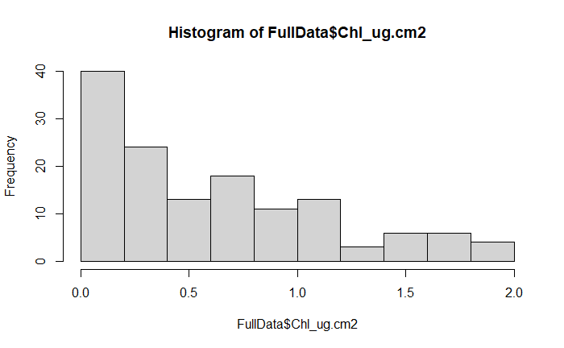

```r
##Chlorophyll
hist(FullData$Chl_ug.cm2)
```

```r
shapiro.test(FullData$Chl_ug.cm2)
```

```
    Shapiro-Wilk normality test

data:  FullData$Chl_ug.cm2
W = 0.89144, p-value = 1.32e-08
```

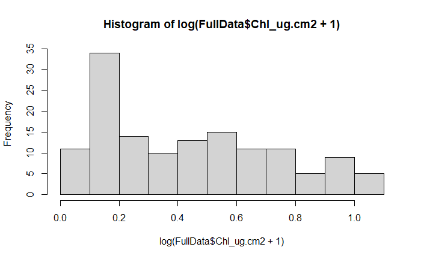

```r
# Not Normal

#Natural log+1 transformation
hist(log(FullData$Chl_ug.cm2+1))
```

```r
shapiro.test(log(FullData$Chl_ug.cm2+1))
```

```
    Shapiro-Wilk normality test

data:  log(FullData$Chl_ug.cm2 + 1)
W = 0.92904, p-value = 2.072e-06
```

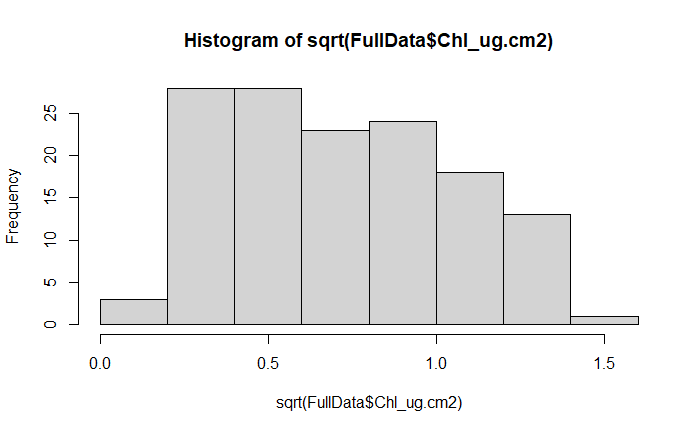

```r
# Not Normal

#Square root transformation
hist(sqrt(FullData$Chl_ug.cm2))
```

```r
shapiro.test(sqrt(FullData$Chl_ug.cm2))
```

```
    Shapiro-Wilk normality test

data:  sqrt(FullData$Chl_ug.cm2)
W = 0.95913, p-value = 0.0003913
```

```r
# Not Normal
```

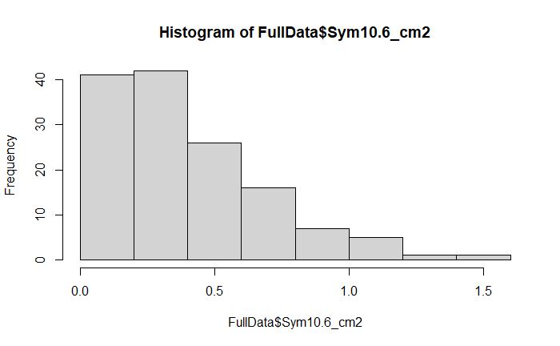

```r
##Symbionts
hist(FullData$Sym10.6_cm2)
```

```r
shapiro.test(FullData$Sym10.6_cm2)
```

```
    Shapiro-Wilk normality test

data:  FullData$Sym10.6_cm2
W = 0.9028, p-value = 4.907e-08
```

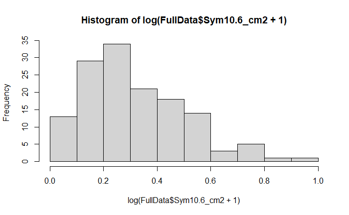

```r
# Not Normal

#Natural log+1 transformation
hist(log(FullData$Sym10.6_cm2+1))
```

```r
shapiro.test(log(FullData$Sym10.6_cm2+1))
```

```
    Shapiro-Wilk normality test

data:  log(FullData$Sym10.6_cm2 + 1)
W = 0.94815, p-value = 4.592e-05
```

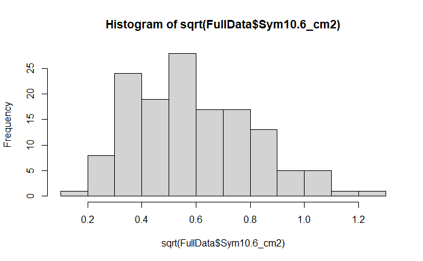

```r
# Not Normal

#Square root transformation
hist(sqrt(FullData$Sym10.6_cm2))
```

```r
shapiro.test(sqrt(FullData$Sym10.6_cm2))
```

```
    Shapiro-Wilk normality test

data:  sqrt(FullData$Sym10.6_cm2)
W = 0.97988, p-value = 0.03802
```

```r
# Not Normal
```

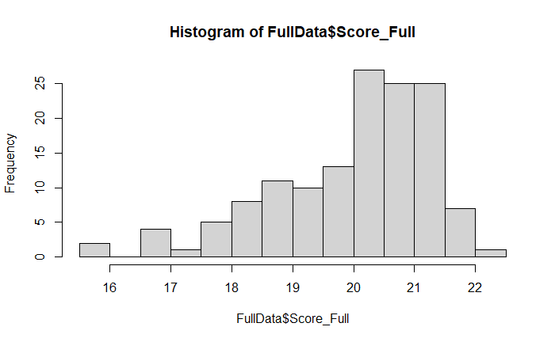

```r
##Color Score with Full Dataset
hist(FullData$Score_Full)
```

```r
shapiro.test(FullData$Score_Full)
```

```
    Shapiro-Wilk normality test

data:  FullData$Score_Full
W = 0.9234, p-value = 8.247e-07
```

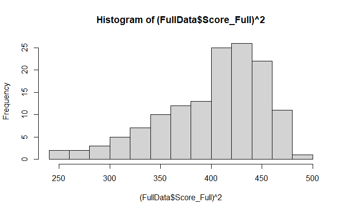

```r
# Not Normal

#Square transformation
hist((FullData$Score_Full)^2)
```

```r
shapiro.test((FullData$Score_Full)^2)
```

```
    Shapiro-Wilk normality test

data:  (FullData$Score_Full)^2
W = 0.94099, p-value = 1.315e-05
```

```r
# Not Normal
```

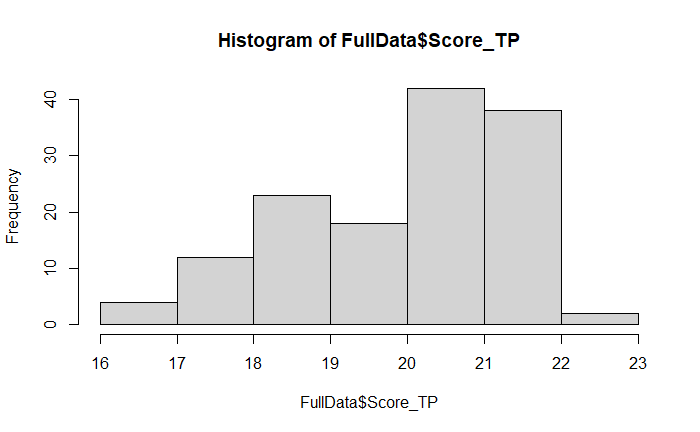

```r
##Color Score by Timepoints
hist(FullData$Score_TP)
```

```r
shapiro.test(FullData$Score_TP)
```

```
    Shapiro-Wilk normality test

data:  FullData$Score_TP
W = 0.94482, p-value = 2.544e-05
```

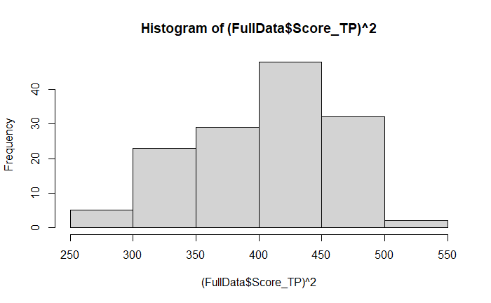

```r
# Not Normal

#Square transformation
hist((FullData$Score_TP)^2)
```

```r
shapiro.test((FullData$Score_TP)^2)
```

```
    Shapiro-Wilk normality test

data:  (FullData$Score_TP)^2
W = 0.95432, p-value = 0.0001446
```

```r
# Not Normal
```

None of the variables are normally distributed.

### Checking Correlation

Checking correlation between each Color Score calculation with traditional bleaching metrics. Using Pearson correlation to check for linear correlation.

```r
names(FullData)
```

```
 [1] "ID"          "TimeP"       "Site"        "Genotype"    "Treat"       "Treatment"
 [7] "Seas"        "Set"         "Score_Full"  "Score_TP"    "RandN"       "SA_cm2"
[13] "Chl_ug.cm2"  "Sym10.6_cm2"
```

```r
rcorr(as.matrix(FullData[,c("Score_Full", "Score_TP", "Chl_ug.cm2", "Sym10.6_cm2")], type="pearson"))
```

```
            Score_Full Score_TP Chl_ug.cm2 Sym10.6_cm2
Score_Full        1.00     0.90       0.74        0.63
Score_TP          0.90     1.00       0.74        0.60
Chl_ug.cm2        0.74     0.74       1.00        0.60
Sym10.6_cm2       0.63     0.60       0.60        1.00

n
            Score_Full Score_TP Chl_ug.cm2 Sym10.6_cm2
Score_Full         139      139        138         139
Score_TP           139      139        138         139
Chl_ug.cm2         138      138        138         138
Sym10.6_cm2        139      139        138         139

P
            Score_Full Score_TP Chl_ug.cm2 Sym10.6_cm2
Score_Full              0        0          0
Score_TP     0                   0          0
Chl_ug.cm2   0          0                   0
Sym10.6_cm2  0          0        0
```

Both metrics of Color Score (calculated from different subset strategies) are highly correlated with both Chlorophyll concentration and Symbiont density.

The two metrics of Color Score are highly correlated with each other (0.90).

Color Score calculated from the Full set and Color Score calculated from each Timepoint are similar (.74) in their correlations with Chlorophyll concentration (0.74) and with Symbiont density (0.60-0.63). Additionally, these are on par with the correlation between Chlorophyll and Symbionts (0.60)

# Model Chlorophyll ~ Color

## Full Set

### Model Selection

```r
#Compare Model Distributions
Chl_Full.glm.gaus<-glm(Chl_ug.cm2~Score_Full, data=FullData, family=gaussian(link="identity"))
Chl_Full.glm.gaus.l<-glm(Chl_ug.cm2~Score_Full, data=FullData, family=gaussian(link="log"))
Chl_Full.glm.gaus.i<-glm(Chl_ug.cm2~Score_Full, data=FullData, family=gaussian(link="inverse"))

Chl_Full.glm.gam.l<-glm(Chl_ug.cm2~Score_Full, data=FullData, family=Gamma(link="log"))
Chl_Full.glm.gam.i<-glm(Chl_ug.cm2~Score_Full, data=FullData, family=Gamma(link="inverse"))

#AIC Model Comparison
AIC(Chl_Full.glm.gaus, Chl_Full.glm.gaus.l, Chl_Full.glm.gaus.i, Chl_Full.glm.gam.l, Chl_Full.glm.gam.i)
```

|  | df | AIC |
| --- | --- | --- |
| Chl_Full.glm.gaus | 3 | 106.22802 |
| Chl_Full.glm.gaus.l | 3 | 33.78081 |
| Chl_Full.glm.gaus.i | 3 | 62.51820 |
| Chl_Full.glm.gam.l | 3 | -23.18292 |
| Chl_Full.glm.gam.i | 3 | 10.99572 |

Gamma distribution with log link has the best model fit (lowest AIC)

### Model Results

```r
#Model Results
summary(Chl_Full.glm.gam.l)
```

```
Call:
glm(formula = Chl_ug.cm2 ~ Score_Full, family = Gamma(link = "log"),
    data = FullData)

Coefficients:
            Estimate Std. Error t value Pr(>|t|)
(Intercept) -13.7795     0.7279  -18.93   <2e-16 ***
Score_Full    0.6494     0.0363   17.89   <2e-16 ***
---
Signif. codes:  0 ‘***’ 0.001 ‘**’ 0.01 ‘*’ 0.05 ‘.’ 0.1 ‘ ’ 1

(Dispersion parameter for Gamma family taken to be 0.3143071)

    Null deviance: 125.258  on 137  degrees of freedom
Residual deviance:  40.162  on 136  degrees of freedom
  (1 observation deleted due to missingness)
AIC: -23.183

Number of Fisher Scoring iterations: 7
```

```r
#Effect Size of Color Score
eta_squared(Chl_Full.glm.gam.l, partial=FALSE)
```

```
# Effect Size for ANOVA (Type I)

Parameter  | Eta2 |       95% CI
--------------------------------
Score_Full | 0.55 | [0.46, 1.00]

- One-sided CIs: upper bound fixed at [1.00].
```

```r
##Save model results
Chl_FUll.glm.res<-data.frame(summary(Chl_Full.glm.gam.l)$coefficients)
rownames(Chl_FUll.glm.res)[1]<-"Intercept"
Chl_FUll.glm.res$Predictor<-rownames(Chl_FUll.glm.res)
Chl_FUll.glm.res$EtaSq<-c(NA,eta_squared(Chl_Full.glm.gam.l, partial=FALSE)$Eta2)
Chl_FUll.glm.res$Response<-rep("Chlorophyll", nrow(Chl_FUll.glm.res))
Chl_FUll.glm.res<-Chl_FUll.glm.res %>% dplyr::rename( p.value = "Pr...t..")
Chl_FUll.glm.res<-Chl_FUll.glm.res %>% dplyr::rename( Std.Error = "Std..Error")
Chl_FUll.glm.res$Null.Dev<-c(summary(Chl_Full.glm.gam.l)$null.deviance, summary(Chl_Full.glm.gam.l)$df.null)
Chl_FUll.glm.res$Resid.Dev<-c(summary(Chl_Full.glm.gam.l)$deviance, summary(Chl_Full.glm.gam.l)$df.residual)
```

Color Score calculated for the Full dataset significantly predicts Chlorophyll (p< 2e-16) and explains 55% (Eta squared 0.55) of the variance.

#### Check Residuals

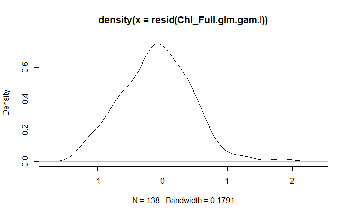

```r
##Check Normality of Residuals
#Distribution
plot(density(resid(Chl_Full.glm.gam.l)))
```

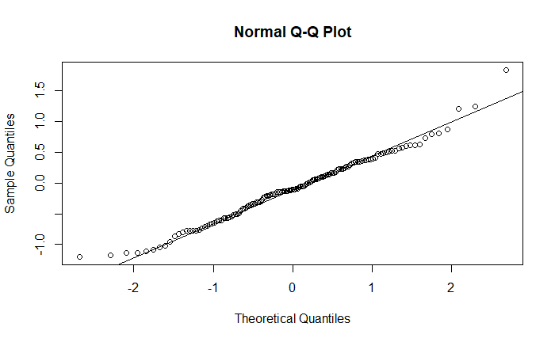

```r
#Q-Q plot
qqnorm(resid(Chl_Full.glm.gam.l)); qqline(resid(Chl_Full.glm.gam.l))
```

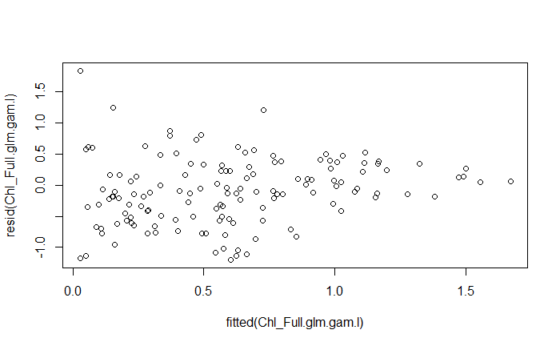

```r
##Check Variance of Residuals across Fitted Values
plot(fitted(Chl_Full.glm.gam.l), resid(Chl_Full.glm.gam.l))
```

Residuals look good.

### Plot Model

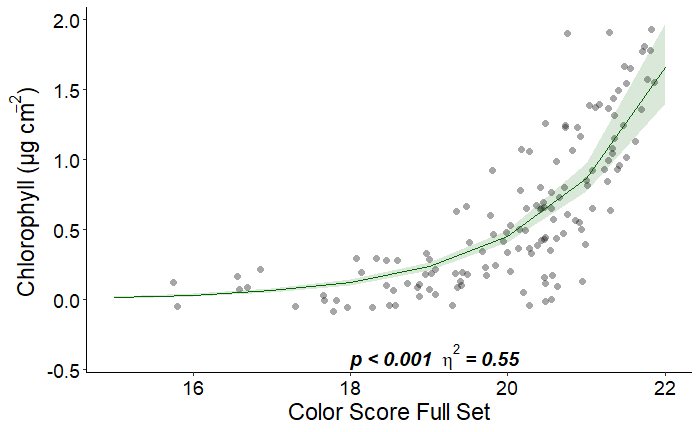

```r
Chl_Full.mod.plot<-plot(ggpredict(Chl_Full.glm.gam.l , terms="Score_Full"), rawdata=TRUE, colors="darkgreen", jitter=TRUE)+
  labs(x="Color Score Full Set", y=expression(paste('Chlorophyll (\u03BCg cm'^-2*") ")), title=NULL)+
  theme_classic()+
  theme(axis.title.x = element_text(size = axis.title.sz),
        axis.title.y = element_text(size = axis.title.sz),
        axis.text.x=element_text(size=axis.txt.sz, colour="black"),
        axis.text.y=element_text(size=axis.txt.sz, colour="black"))+
        annotate("text", x=18, y=-.4, label=expression(bolditalic(paste("p < 0.001  ", eta^2, " = 0.55 "))),size=sig.sz, hjust = 0);Chl_Full.mod.plot
```

```r
NA
NA
```

## Each Timepoint

### Model Selection

```r
#Compare Model Distributions
Chl_TP.glm.gaus<-glm(Chl_ug.cm2~Score_TP, data=FullData, family=gaussian(link="identity"))
Chl_TP.glm.gaus.l<-glm(Chl_ug.cm2~Score_TP, data=FullData, family=gaussian(link="log"))
Chl_TP.glm.gaus.i<-glm(Chl_ug.cm2~Score_TP, data=FullData, family=gaussian(link="inverse"))

Chl_TP.glm.gam.l<-glm(Chl_ug.cm2~Score_TP, data=FullData, family=Gamma(link="log"))
Chl_TP.glm.gam.i<-glm(Chl_ug.cm2~Score_TP, data=FullData, family=Gamma(link="inverse"))

#AIC Model Comparison
AIC(Chl_TP.glm.gaus, Chl_TP.glm.gaus.l, Chl_TP.glm.gaus.i, Chl_TP.glm.gam.l, Chl_TP.glm.gam.i)
```

|  | df | AIC |
| --- | --- | --- |
| Chl_TP.glm.gaus | 3 | 107.01396 |
| Chl_TP.glm.gaus.l | 3 | 73.29137 |
| Chl_TP.glm.gaus.i | 3 | 113.11704 |
| Chl_TP.glm.gam.l | 3 | 15.81462 |
| Chl_TP.glm.gam.i | 3 | 49.90651 |

Gamma distribution with log link has the best model fit (lowest AIC)

### Model Results

```r
#Model Results
summary(Chl_TP.glm.gam.l)
```

```
Call:
glm(formula = Chl_ug.cm2 ~ Score_TP, family = Gamma(link = "log"),
    data = FullData)

Coefficients:
             Estimate Std. Error t value Pr(>|t|)
(Intercept) -11.39990    0.78526  -14.52   <2e-16 ***
Score_TP      0.53267    0.03914   13.61   <2e-16 ***
---
Signif. codes:  0 ‘***’ 0.001 ‘**’ 0.01 ‘*’ 0.05 ‘.’ 0.1 ‘ ’ 1

(Dispersion parameter for Gamma family taken to be 0.4395902)

    Null deviance: 125.258  on 137  degrees of freedom
Residual deviance:  52.498  on 136  degrees of freedom
  (1 observation deleted due to missingness)
AIC: 15.815

Number of Fisher Scoring iterations: 6
```

```r
#Effect Size of Color Score
eta_squared(Chl_TP.glm.gam.l, partial=FALSE)
```

```
# Effect Size for ANOVA (Type I)

Parameter | Eta2 |       95% CI
-------------------------------
Score_TP  | 0.54 | [0.45, 1.00]

- One-sided CIs: upper bound fixed at [1.00].
```

```r
##Save model results
Chl_TP.glm.res<-data.frame(summary(Chl_TP.glm.gam.l)$coefficients)
rownames(Chl_TP.glm.res)[1]<-"Intercept"
Chl_TP.glm.res$Predictor<-rownames(Chl_TP.glm.res)
Chl_TP.glm.res$EtaSq<-c(NA,eta_squared(Chl_TP.glm.gam.l, partial=FALSE)$Eta2)
Chl_TP.glm.res$Response<-rep("Chlorophyll", nrow(Chl_TP.glm.res))
Chl_TP.glm.res<-Chl_TP.glm.res %>% dplyr::rename( p.value = "Pr...t..")
Chl_TP.glm.res<-Chl_TP.glm.res %>% dplyr::rename( Std.Error = "Std..Error")
Chl_TP.glm.res$Null.Dev<-c(summary(Chl_TP.glm.gam.l)$null.deviance, summary(Chl_TP.glm.gam.l)$df.null)
Chl_TP.glm.res$Resid.Dev<-c(summary(Chl_TP.glm.gam.l)$deviance, summary(Chl_TP.glm.gam.l)$df.residual)
```

#### Check Residuals

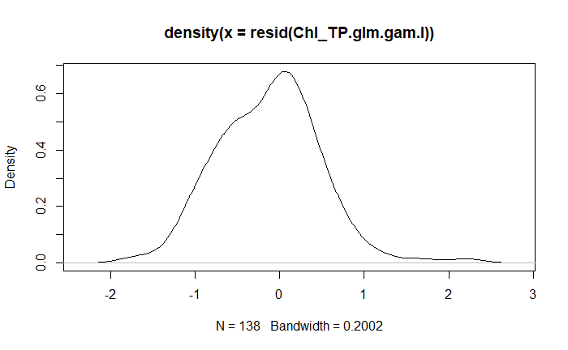

```r
##Check Normality of Residuals
#Distribution
plot(density(resid(Chl_TP.glm.gam.l)))
```

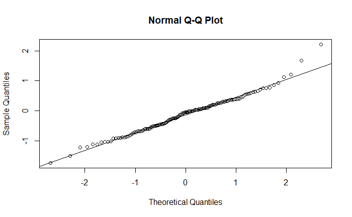

```r
#Q-Q plot
qqnorm(resid(Chl_TP.glm.gam.l)); qqline(resid(Chl_TP.glm.gam.l))
```

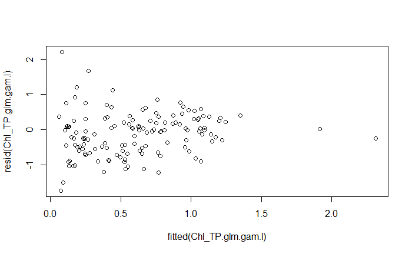

```r
##Check Variance of Residuals across Fitted Values
plot(fitted(Chl_TP.glm.gam.l), resid(Chl_TP.glm.gam.l))
```

Residuals look good.

### Plot Model

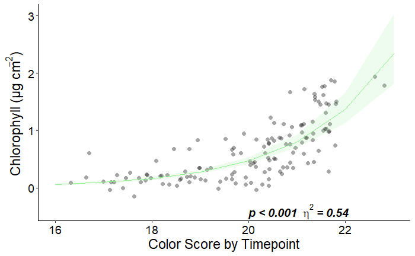

```r
Chl_TP.mod.plot<-plot(ggpredict(Chl_TP.glm.gam.l , terms="Score_TP"), rawdata=TRUE, colors="lightgreen", jitter=TRUE)+
  labs(x="Color Score by Timepoint", y=expression(paste('Chlorophyll (\u03BCg cm'^-2*") ")), title=NULL)+
  theme_classic()+
  theme(axis.title.x = element_text(size = axis.title.sz),
        axis.title.y = element_text(size = axis.title.sz),
        axis.text.x=element_text(size=axis.txt.sz, colour="black"),
        axis.text.y=element_text(size=axis.txt.sz, colour="black"))+
        annotate("text", x=20, y=-.4, label=expression(bolditalic(paste("p < 0.001  ", eta^2, " = 0.54 "))),size=sig.sz, hjust = 0);Chl_TP.mod.plot
```

# Model Symbionts ~ Color

## Full Set

### Model Selection

```r
#Compare Model Distributions
Sym_Full.glm.gaus<-glm(Sym10.6_cm2~Score_Full, data=FullData, family=gaussian(link="identity"))
Sym_Full.glm.gaus.l<-glm(Sym10.6_cm2~Score_Full, data=FullData, family=gaussian(link="log"))
Sym_Full.glm.gaus.i<-glm(Sym10.6_cm2~Score_Full, data=FullData, family=gaussian(link="inverse"))

Sym_Full.glm.gam.l<-glm(Sym10.6_cm2~Score_Full, data=FullData, family=Gamma(link="log"))
Sym_Full.glm.gam.i<-glm(Sym10.6_cm2~Score_Full, data=FullData, family=Gamma(link="inverse"))


#AIC Model Comparison
AIC(Sym_Full.glm.gaus, Sym_Full.glm.gaus.l, Sym_Full.glm.gaus.i, Sym_Full.glm.gam.l, Sym_Full.glm.gam.i)
```

|  | df | AIC |
| --- | --- | --- |
| Sym_Full.glm.gaus | 3 | -18.74757 |
| Sym_Full.glm.gaus.l | 3 | -38.70489 |
| Sym_Full.glm.gaus.i | 3 | -37.58155 |
| Sym_Full.glm.gam.l | 3 | -103.08744 |
| Sym_Full.glm.gam.i | 3 | -99.81316 |

Gamma distribution with log link has the best model fit (lowest AIC).

### Model Results

```r
#Model Results
summary(Sym_Full.glm.gam.l)
```

```
Call:
glm(formula = Sym10.6_cm2 ~ Score_Full, family = Gamma(link = "log"),
    data = FullData)

Coefficients:
            Estimate Std. Error t value Pr(>|t|)
(Intercept) -9.39808    0.66480  -14.14   <2e-16 ***
Score_Full   0.41739    0.03317   12.58   <2e-16 ***
---
Signif. codes:  0 ‘***’ 0.001 ‘**’ 0.01 ‘*’ 0.05 ‘.’ 0.1 ‘ ’ 1

(Dispersion parameter for Gamma family taken to be 0.2639406)

    Null deviance: 75.854  on 138  degrees of freedom
Residual deviance: 38.124  on 137  degrees of freedom
AIC: -103.09

Number of Fisher Scoring iterations: 6
```

```r
#Effect Size of Color Score
eta_squared(Sym_Full.glm.gam.l, partial=FALSE)
```

```
# Effect Size for ANOVA (Type I)

Parameter  | Eta2 |       95% CI
--------------------------------
Score_Full | 0.40 | [0.30, 1.00]

- One-sided CIs: upper bound fixed at [1.00].
```

```r
##Save model results
Sym_Full.glm.res<-data.frame(summary(Sym_Full.glm.gam.l)$coefficients)
rownames(Sym_Full.glm.res)[1]<-"Intercept"
Sym_Full.glm.res$Predictor<-rownames(Sym_Full.glm.res)
Sym_Full.glm.res$EtaSq<-c(NA,eta_squared(Sym_Full.glm.gam.l, partial=FALSE)$Eta2)
Sym_Full.glm.res$Response<-rep("Symbionts", nrow(Sym_Full.glm.res))
Sym_Full.glm.res<-Sym_Full.glm.res %>% dplyr::rename( p.value = "Pr...t..")
Sym_Full.glm.res<-Sym_Full.glm.res %>% dplyr::rename( Std.Error = "Std..Error")
Sym_Full.glm.res$Null.Dev<-c(summary(Sym_Full.glm.gam.l)$null.deviance, summary(Sym_Full.glm.gam.l)$df.null)
Sym_Full.glm.res$Resid.Dev<-c(summary(Sym_Full.glm.gam.l)$deviance, summary(Sym_Full.glm.gam.l)$df.residual)
```

#### Check Residuals

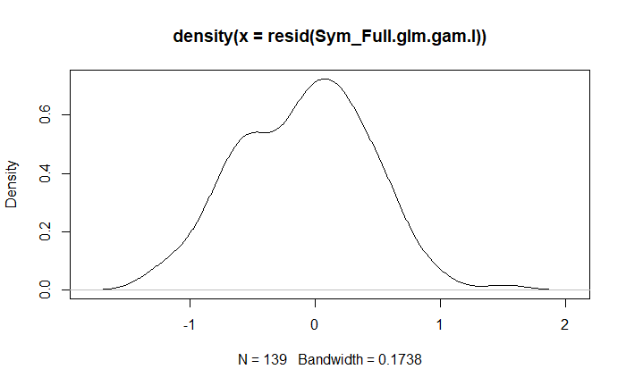

```r
##Check Normality of Residuals
#Distribution
plot(density(resid(Sym_Full.glm.gam.l)))
```

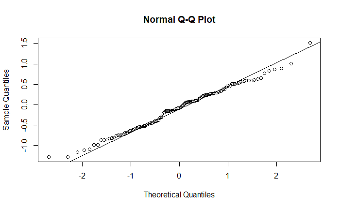

```r
#Q-Q plot
qqnorm(resid(Sym_Full.glm.gam.l)); qqline(resid(Sym_Full.glm.gam.l))
```

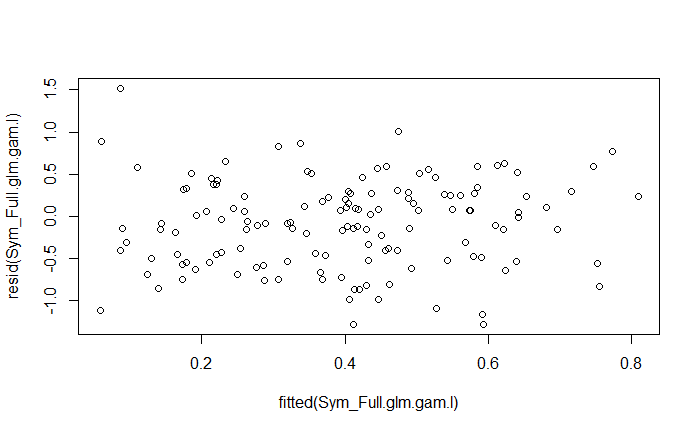

```r
##Check Variance of Residuals across Fitted Values
plot(fitted(Sym_Full.glm.gam.l), resid(Sym_Full.glm.gam.l))
```

Residuals look good.

### Plot Model

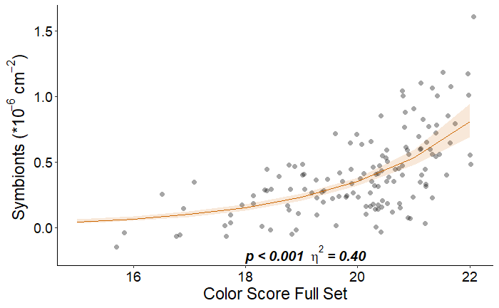

```r
Sym_Full.mod.plot<-plot(ggpredict(Sym_Full.glm.gam.l , terms="Score_Full"), rawdata=TRUE, colors="darkorange3", jitter=TRUE)+
  labs(x="Color Score Full Set", y=expression(paste('Symbionts (*10'^-6* ' cm'^-2*") ")), title=NULL)+
  theme_classic()+
  theme(axis.title.x = element_text(size = axis.title.sz),
        axis.title.y = element_text(size = axis.title.sz),
        axis.text.x=element_text(size=axis.txt.sz, colour="black"),
        axis.text.y=element_text(size=axis.txt.sz, colour="black"))+
        annotate("text", x=18, y=-.2, label=expression(bolditalic(paste("p < 0.001  ", eta^2, " = 0.40 "))),size=sig.sz, hjust = 0);Sym_Full.mod.plot
```

```r
NA
NA
```

## Each Timepoint

### Model Selection

```r
#Compare Model Distributions
Sym_TP.glm.gaus<-glm(Sym10.6_cm2~Score_TP, data=FullData, family=gaussian(link="identity"))
Sym_TP.glm.gaus.l<-glm(Sym10.6_cm2~Score_TP, data=FullData, family=gaussian(link="log"))
Sym_TP.glm.gaus.i<-glm(Sym10.6_cm2~Score_TP, data=FullData, family=gaussian(link="inverse"))

Sym_TP.glm.gam.l<-glm(Sym10.6_cm2~Score_TP, data=FullData, family=Gamma(link="log"))
Sym_TP.glm.gam.i<-glm(Sym10.6_cm2~Score_TP, data=FullData, family=Gamma(link="inverse"))

#AIC Model Comparison
AIC(Sym_TP.glm.gaus, Sym_TP.glm.gaus.l, Sym_TP.glm.gaus.i, Sym_TP.glm.gam.l, Sym_TP.glm.gam.i)
```

|  | df | AIC |
| --- | --- | --- |
| Sym_TP.glm.gaus | 3 | -11.821041 |
| Sym_TP.glm.gaus.l | 3 | -14.313327 |
| Sym_TP.glm.gaus.i | 3 | -5.149828 |
| Sym_TP.glm.gam.l | 3 | -87.386719 |
| Sym_TP.glm.gam.i | 3 | -75.235241 |

Gamma distribution with log link has the best model fit (lowest AIC).

### Model Results

```r
#Model Results
summary(Sym_TP.glm.gam.l)
```

```
Call:
glm(formula = Sym10.6_cm2 ~ Score_TP, family = Gamma(link = "log"),
    data = FullData)

Coefficients:
            Estimate Std. Error t value Pr(>|t|)
(Intercept) -8.24630    0.62659  -13.16   <2e-16 ***
Score_TP     0.36059    0.03125   11.54   <2e-16 ***
---
Signif. codes:  0 ‘***’ 0.001 ‘**’ 0.01 ‘*’ 0.05 ‘.’ 0.1 ‘ ’ 1

(Dispersion parameter for Gamma family taken to be 0.281783)

    Null deviance: 75.854  on 138  degrees of freedom
Residual deviance: 42.464  on 137  degrees of freedom
AIC: -87.387

Number of Fisher Scoring iterations: 5
```

```r
#Effect Size of Color Score
eta_squared(Sym_TP.glm.gam.l, partial=FALSE)
```

```
# Effect Size for ANOVA (Type I)

Parameter | Eta2 |       95% CI
-------------------------------
Score_TP  | 0.37 | [0.26, 1.00]

- One-sided CIs: upper bound fixed at [1.00].
```

```r
##Save model results
Sym_TP.glm.res<-data.frame(summary(Sym_TP.glm.gam.l)$coefficients)
rownames(Sym_TP.glm.res)[1]<-"Intercept"
Sym_TP.glm.res$Predictor<-rownames(Sym_TP.glm.res)
Sym_TP.glm.res$EtaSq<-c(NA,eta_squared(Sym_TP.glm.gam.l, partial=FALSE)$Eta2)
Sym_TP.glm.res$Response<-rep("Symbionts", nrow(Sym_TP.glm.res))
Sym_TP.glm.res<-Sym_TP.glm.res %>% dplyr::rename( p.value = "Pr...t..")
Sym_TP.glm.res<-Sym_TP.glm.res %>% dplyr::rename( Std.Error = "Std..Error")
Sym_TP.glm.res$Null.Dev<-c(summary(Sym_TP.glm.gam.l)$null.deviance, summary(Sym_TP.glm.gam.l)$df.null)
Sym_TP.glm.res$Resid.Dev<-c(summary(Sym_TP.glm.gam.l)$deviance, summary(Sym_TP.glm.gam.l)$df.residual)
```

#### Check Residuals

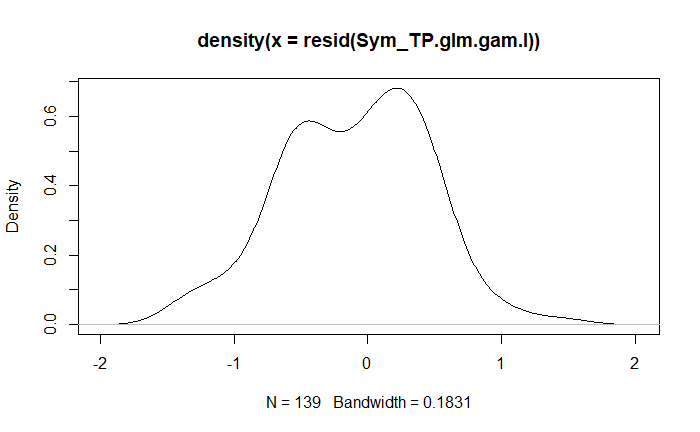

```r
##Check Normality of Residuals
#Distribution
plot(density(resid(Sym_TP.glm.gam.l)))
```

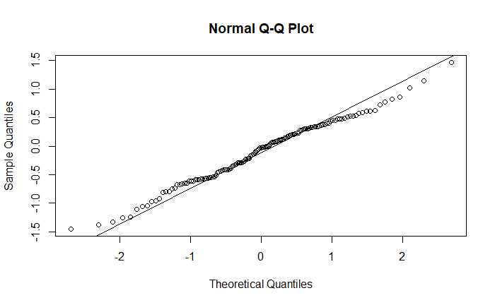

```r
#Q-Q plot
qqnorm(resid(Sym_TP.glm.gam.l)); qqline(resid(Sym_TP.glm.gam.l))
```

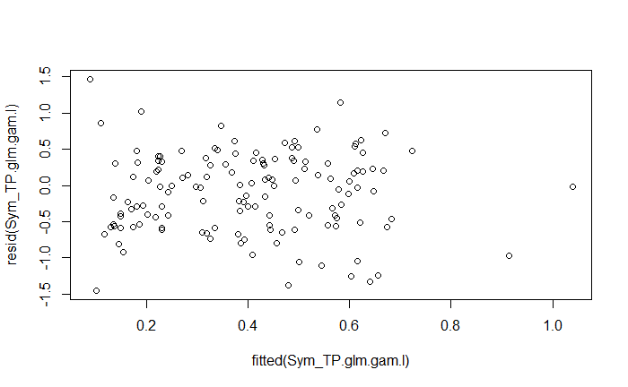

```r
##Check Variance of Residuals across Fitted Values
plot(fitted(Sym_TP.glm.gam.l), resid(Sym_TP.glm.gam.l))
```

Residuals look good.

### Plot Model

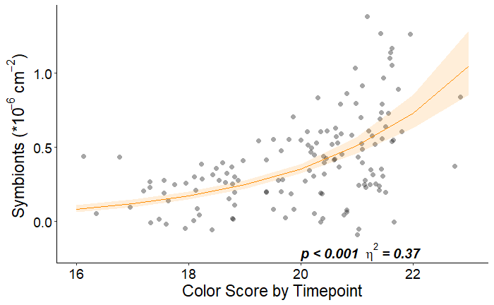

```r
Sym_TP.mod.plot<-plot(ggpredict(Sym_TP.glm.gam.l , terms="Score_TP"), rawdata=TRUE, colors="darkorange", jitter=TRUE)+
  labs(x="Color Score by Timepoint", y=expression(paste('Symbionts (*10'^-6* ' cm'^-2*") ")), title=NULL)+
  theme_classic()+
  theme(axis.title.x = element_text(size = axis.title.sz),
        axis.title.y = element_text(size = axis.title.sz),
        axis.text.x=element_text(size=axis.txt.sz, colour="black"),
        axis.text.y=element_text(size=axis.txt.sz, colour="black"))+
        annotate("text", x=20, y=-.2, label=expression(bolditalic(paste("p < 0.001  ", eta^2, " = 0.37 "))),size=sig.sz, hjust = 0);Sym_TP.mod.plot
```

# Model Predictions

Using similar models of Bleaching Metric ~ Color Score developed for Summer 1 (Timepoint W2) to test the ability to use Color Score to predict the Bleaching Metric in Summer 2 (Timepoint M1) and Winter (Timepoint M4) seasonal timepoints.

## Model Chl ~ Color

### Develop Summer 1 Model

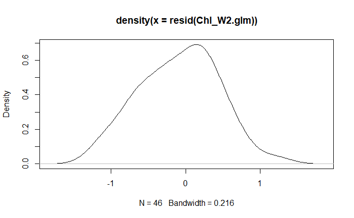

```r
##Model with Gamma Log Link
Chl_W2.glm<-glm(Chl_ug.cm2~Score_TP, data=subset(FullData, TimeP=="W2"), family=Gamma(link="log"))


##Check Residuals
#Distribution
plot(density(resid(Chl_W2.glm)))
```

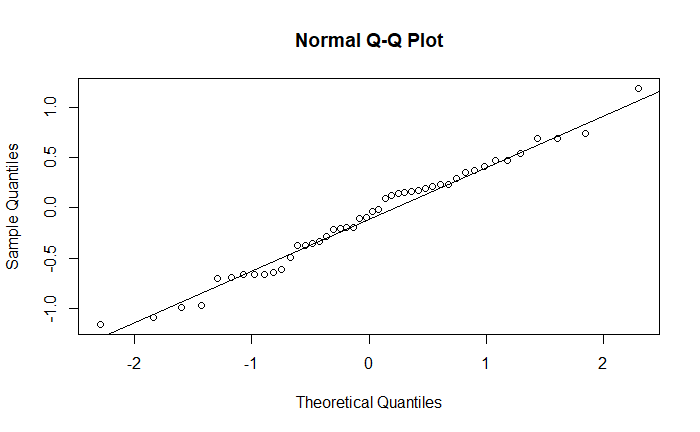

```r
#Q-Q plot
qqnorm(resid(Chl_W2.glm)); qqline(resid(Chl_W2.glm))
```

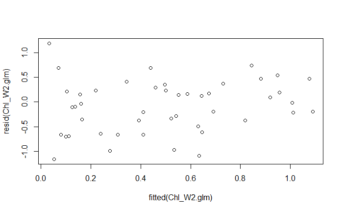

```r
##Residuals vs Fitted Values
plot(fitted(Chl_W2.glm), resid(Chl_W2.glm))
```

```r
##Model Results
summary(Chl_W2.glm)
```

```
Call:
glm(formula = Chl_ug.cm2 ~ Score_TP, family = Gamma(link = "log"),
    data = subset(FullData, TimeP == "W2"))

Coefficients:
             Estimate Std. Error t value Pr(>|t|)
(Intercept) -13.54283    1.07868  -12.55 3.84e-16 ***
Score_TP      0.62577    0.05372   11.65 4.92e-15 ***
---
Signif. codes:  0 ‘***’ 0.001 ‘**’ 0.01 ‘*’ 0.05 ‘.’ 0.1 ‘ ’ 1

(Dispersion parameter for Gamma family taken to be 0.2717857)

    Null deviance: 44.761  on 45  degrees of freedom
Residual deviance: 12.929  on 44  degrees of freedom
  (1 observation deleted due to missingness)
AIC: -25.528

Number of Fisher Scoring iterations: 8
```

```r
#Effect Size of Color Score
eta_squared(Chl_W2.glm, partial=FALSE)
```

```
# Effect Size for ANOVA (Type I)

Parameter | Eta2 |       95% CI
-------------------------------
Score_TP  | 0.55 | [0.39, 1.00]

- One-sided CIs: upper bound fixed at [1.00].
```

```r
##Save model results
Chl_W2.glm.res<-data.frame(summary(Chl_W2.glm)$coefficients)
Chl_W2.glm.res$Predictor<-c("Intercept", "Color Summer 1")
Chl_W2.glm.res$EtaSq<-c(NA,eta_squared(Chl_W2.glm, partial=FALSE)$Eta2)
Chl_W2.glm.res$Response<-rep("Chlorophyll Summer 1", nrow(Chl_W2.glm.res))
Chl_W2.glm.res<-Chl_W2.glm.res %>% dplyr::rename( p.value = "Pr...t..")
Chl_W2.glm.res<-Chl_W2.glm.res %>% dplyr::rename( Std.Error = "Std..Error")
Chl_W2.glm.res$Null.Dev<-c(summary(Chl_W2.glm)$null.deviance, summary(Chl_W2.glm)$df.null)
Chl_W2.glm.res$Resid.Dev<-c(summary(Chl_W2.glm)$deviance, summary(Chl_W2.glm)$df.residual)
```

### Predict Summer 2

```r
##Predicted values on Response scale
M1_Chl_predict<-data.frame(Predicted=predict(Chl_W2.glm, newdata=data.frame(Score_TP=c(FullData$Score_TP[which(FullData$TimeP=="M1")])), type="response"))

##Compare with Measured values
M1_Chl_predict$Measured<-FullData$Chl_ug.cm2[which(FullData$TimeP=="M1")]

##Test correlation between Predicted and Measured values
cor.test(M1_Chl_predict$Predicted, M1_Chl_predict$Measured, method="pearson")
```

```
    Pearson's product-moment correlation

data:  M1_Chl_predict$Predicted and M1_Chl_predict$Measured
t = 12.351, df = 42, p-value = 1.435e-15
alternative hypothesis: true correlation is not equal to 0
95 percent confidence interval:
 0.7985481 0.9362515
sample estimates:
      cor
0.8855001
```

The measured values of Summer 2 Chlorophyll are significantly (p < 0.001) correlated with those predicted from Color Score using the model developed in Summer 1.

#### Plot Predicted vs Measured

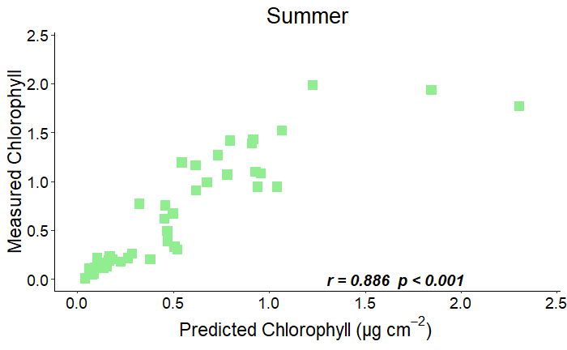

```r
Chl_M1.pred.plot<-ggplot(M1_Chl_predict, aes(x=Predicted, y=Measured))+
    geom_point(size=point.sz, colour="lightgreen", pch=15)+
  labs(x=expression(paste('Predicted Chlorophyll (\u03BCg cm'^-2*") ")), y="Measured Chlorophyll", title="Summer")+
  theme_classic()+
  ylim(0,2.4)+
  xlim(0,2.4)+
  theme(axis.title.x = element_text(size = axis.title.sz),
        axis.title.y = element_text(size = axis.title.sz),
        axis.text.x=element_text(size=axis.txt.sz, colour="black"),
        axis.text.y=element_text(size=axis.txt.sz, colour="black"),
        plot.title = element_text(size = plot.title.sz, colour="black", hjust = 0.5))+
  annotate("text",  x=1.3, y=0, label="r = 0.886  p < 0.001", fontface="bold.italic",size=sig.sz, hjust = 0);Chl_M1.pred.plot
```

### Predict Winter

```r
##Predicted values on Response scale
M4_Chl_predict<-data.frame(Predicted=predict(Chl_W2.glm, newdata=data.frame(Score_TP=c(FullData$Score_TP[which(FullData$TimeP=="M4")])), type="response"))

##Compare with Measured values
M4_Chl_predict$Measured<-FullData$Chl_ug.cm2[which(FullData$TimeP=="M4")]

##Test correlation between Predicted and Measured values
cor.test(M4_Chl_predict$Predicted, M4_Chl_predict$Measured, method="pearson")
```

```
    Pearson's product-moment correlation

data:  M4_Chl_predict$Predicted and M4_Chl_predict$Measured
t = 6.2927, df = 46, p-value = 1.053e-07
alternative hypothesis: true correlation is not equal to 0
95 percent confidence interval:
 0.4908769 0.8081120
sample estimates:
      cor
0.6801479
```

The measured values of Winter Chlorophyll are significantly (p < 0.001) correlated with those predicted from Color Score using the model developed in Summer 1.

#### Plot Predicted vs Measured

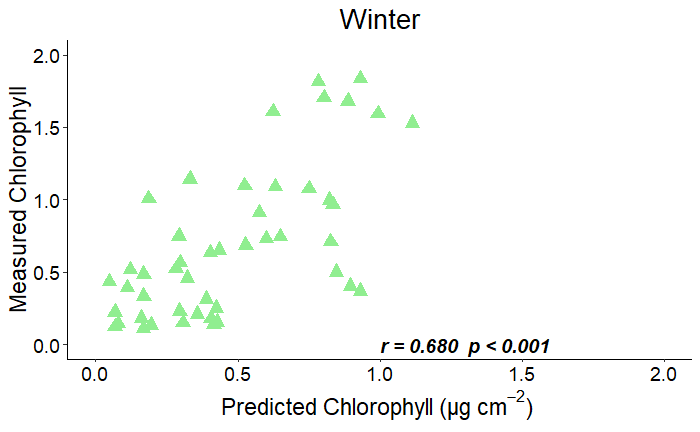

```r
Chl_M4.pred.plot<-ggplot(M4_Chl_predict, aes(x=Predicted, y=Measured))+
    geom_point(size=point.sz, colour="lightgreen", pch=17)+
  labs(x=expression(paste('Predicted Chlorophyll (\u03BCg cm'^-2*") ")), y="Measured Chlorophyll", title="Winter")+
  theme_classic()+
  ylim(0,2)+
  xlim(0,2)+
  theme(axis.title.x = element_text(size = axis.title.sz),
        axis.title.y = element_text(size = axis.title.sz),
        axis.text.x=element_text(size=axis.txt.sz, colour="black"),
        axis.text.y=element_text(size=axis.txt.sz, colour="black"),
        plot.title = element_text(size = plot.title.sz, colour="black", hjust = 0.5))+
  annotate("text",  x=1, y=0, label="r = 0.680  p < 0.001", fontface="bold.italic",size=sig.sz, hjust = 0);Chl_M4.pred.plot
```

## Model Sym ~ Color

### Develop Summer 1 Model

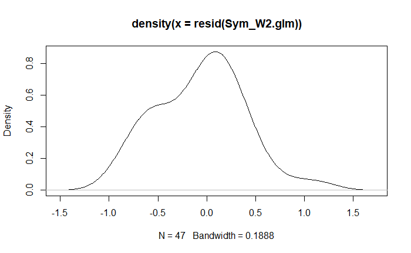

```r
##Model with Gamma Log Link
Sym_W2.glm<-glm(Sym10.6_cm2~Score_TP, data=subset(FullData, TimeP=="W2"), family=Gamma(link="log"))


##Check Residuals
#Distribution
plot(density(resid(Sym_W2.glm)))
```

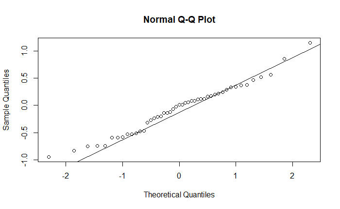

```r
#Q-Q plot
qqnorm(resid(Sym_W2.glm)); qqline(resid(Sym_W2.glm))
```

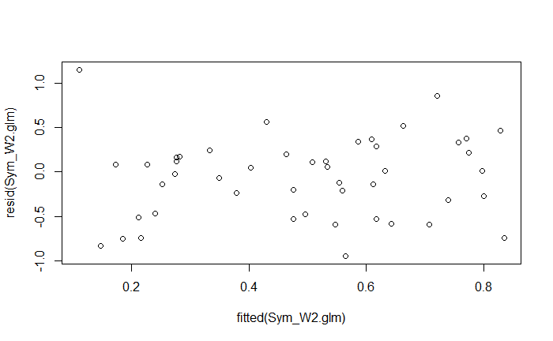

```r
##Residuals vs Fitted Values
plot(fitted(Sym_W2.glm), resid(Sym_W2.glm))
```

```r
##Model Results
summary(Sym_W2.glm)
```

```
Call:
glm(formula = Sym10.6_cm2 ~ Score_TP, family = Gamma(link = "log"),
    data = subset(FullData, TimeP == "W2"))

Coefficients:
            Estimate Std. Error t value Pr(>|t|)
(Intercept) -8.01702    0.95380  -8.405 8.93e-11 ***
Score_TP     0.35983    0.04757   7.564 1.49e-09 ***
---
Signif. codes:  0 ‘***’ 0.001 ‘**’ 0.01 ‘*’ 0.05 ‘.’ 0.1 ‘ ’ 1

(Dispersion parameter for Gamma family taken to be 0.2169318)

    Null deviance: 21.4028  on 46  degrees of freedom
Residual deviance:  9.6517  on 45  degrees of freedom
AIC: -20.18

Number of Fisher Scoring iterations: 6
```

```r
#Effect Size of Color Score
eta_squared(Sym_W2.glm, partial=FALSE)
```

```
# Effect Size for ANOVA (Type I)

Parameter | Eta2 |       95% CI
-------------------------------
Score_TP  | 0.45 | [0.27, 1.00]

- One-sided CIs: upper bound fixed at [1.00].
```

```r
##Save model results
Sym_W2.glm.res<-data.frame(summary(Sym_W2.glm)$coefficients)
Sym_W2.glm.res$Predictor<-c("Intercept", "Color Summer 1")
Sym_W2.glm.res$EtaSq<-c(NA,eta_squared(Sym_W2.glm, partial=FALSE)$Eta2)
Sym_W2.glm.res$Response<-rep("Symbionts Summer 1", nrow(Sym_W2.glm.res))
Sym_W2.glm.res<-Sym_W2.glm.res %>% dplyr::rename( p.value = "Pr...t..")
Sym_W2.glm.res<-Sym_W2.glm.res %>% dplyr::rename( Std.Error = "Std..Error")
Sym_W2.glm.res$Null.Dev<-c(summary(Sym_W2.glm)$null.deviance, summary(Sym_W2.glm)$df.null)
Sym_W2.glm.res$Resid.Dev<-c(summary(Sym_W2.glm)$deviance, summary(Sym_W2.glm)$df.residual)
```

### Predict Summer 2

```r
##Predicted values on Response scale
M1_Sym_predict<-data.frame(Predicted=predict(Sym_W2.glm, newdata=data.frame(Score_TP=c(FullData$Score_TP[which(FullData$TimeP=="M1")])), type="response"))

##Compare with Measured values
M1_Sym_predict$Measured<-FullData$Sym10.6_cm2[which(FullData$TimeP=="M1")]

##Test correlation between Predicted and Measured values
cor.test(M1_Sym_predict$Predicted, M1_Sym_predict$Measured, method="pearson")
```

```
    Pearson's product-moment correlation

data:  M1_Sym_predict$Predicted and M1_Sym_predict$Measured
t = 7.4448, df = 42, p-value = 3.382e-09
alternative hypothesis: true correlation is not equal to 0
95 percent confidence interval:
 0.5893431 0.8588248
sample estimates:
      cor
0.7542556
```

The measured values of Summer 2 Symbiont Density are significantly (p < 0.001) correlated with those predicted from Color Score using the model developed in Summer 1.

#### Plot Predicted vs Measured

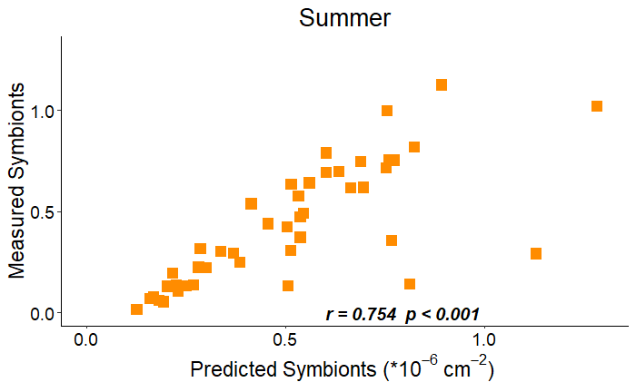

```r
Sym_M1.pred.plot<-ggplot(M1_Sym_predict, aes(x=Predicted, y=Measured))+
    geom_point(size=point.sz, colour="darkorange", pch=15)+
  labs(x=expression(paste('Predicted Symbionts (*10'^-6* ' cm'^-2*") ")), y="Measured Symbionts", title="Summer")+
  theme_classic()+
  xlim(0, 1.3)+
  ylim(0, 1.3)+
  theme(axis.title.x = element_text(size = axis.title.sz),
        axis.title.y = element_text(size = axis.title.sz),
        axis.text.x=element_text(size=axis.txt.sz, colour="black"),
        axis.text.y=element_text(size=axis.txt.sz, colour="black"),
        plot.title = element_text(size = plot.title.sz, colour="black", hjust = 0.5))+
   annotate("text",  x=0.6, y=0, label="r = 0.754  p < 0.001", fontface="bold.italic",size=sig.sz, hjust = 0);Sym_M1.pred.plot
```

### Predict Winter

```r
##Predicted values on Response scale
M4_Sym_predict<-data.frame(Predicted=predict(Sym_W2.glm, newdata=data.frame(Score_TP=c(FullData$Score_TP[which(FullData$TimeP=="M4")])), type="response"))

##Compare with Measured values
M4_Sym_predict$Measured<-FullData$Sym10.6_cm2[which(FullData$TimeP=="M4")]

##Test correlation between Predicted and Measured values
cor.test(M4_Sym_predict$Predicted, M4_Sym_predict$Measured, method="pearson")
```

```
    Pearson's product-moment correlation

data:  M4_Sym_predict$Predicted and M4_Sym_predict$Measured
t = 2.4899, df = 46, p-value = 0.01645
alternative hypothesis: true correlation is not equal to 0
95 percent confidence interval:
 0.06706146 0.57268603
sample estimates:
      cor
0.3446294
```

The measured values of Winter Symbiont Density are significantly (p < 0.05) correlated with those predicted from Color Score using the model developed in Summer 1.

#### Plot Predicted vs Measured

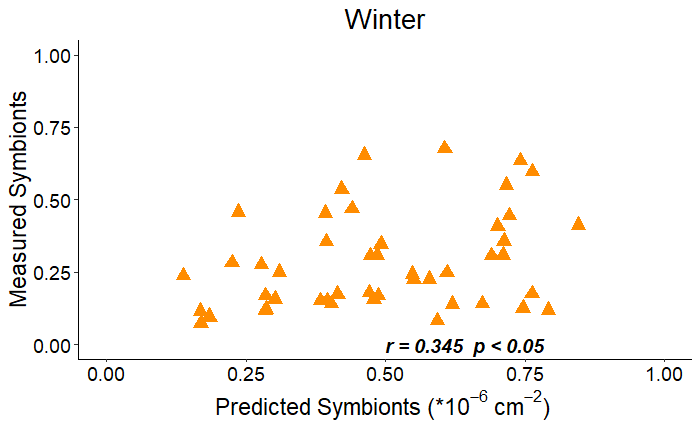

```r
Sym_M4.pred.plot<-ggplot(M4_Sym_predict, aes(x=Predicted, y=Measured))+
    geom_point(size=point.sz, colour="darkorange", pch=17)+
  labs(x=expression(paste('Predicted Symbionts (*10'^-6* ' cm'^-2*") ")), y="Measured Symbionts", title="Winter")+
  theme_classic()+
 xlim(0, 1)+
  ylim(0, 1)+
  theme(axis.title.x = element_text(size = axis.title.sz),
        axis.title.y = element_text(size = axis.title.sz),
        axis.text.x=element_text(size=axis.txt.sz, colour="black"),
        axis.text.y=element_text(size=axis.txt.sz, colour="black"),
        plot.title = element_text(size = plot.title.sz, colour="black", hjust = 0.5))+
   annotate("text",  x=0.5, y=0, label="r = 0.345  p < 0.05", fontface="bold.italic",size=sig.sz, hjust = 0);Sym_M4.pred.plot
```

# Write Out FullData

```r
write.csv(FullData, "Outputs/FullData.csv", row.names=FALSE)
```

# Figures

### Figure 2 Bleaching vs Color Score

```r
##Create Panel
Bleach_Color_Models_fig<-plot_grid(Chl_Full.mod.plot, Chl_TP.mod.plot,
                     Sym_Full.mod.plot, Sym_TP.mod.plot,
                     nrow=2, ncol=2,
                     rel_widths=1, rel_heights=1,
                     labels=c("a", "b", "c", "d"),
                     label_size=panel.lab.sz-2,
                     label_fontface = "bold")
##Save Figure
ggsave(filename="Figures/Figure2_Bleaching_Color_Models.png", plot=Bleach_Color_Models_fig, dpi=300, width=10, height=8, units="in")
```

### Figure 3 Predicted vs Measured Bleaching

```r
##Remove Titles for Panel
Sym_M1.pred.plot<-Sym_M1.pred.plot+labs(title=NULL)
Sym_M4.pred.plot<-Sym_M4.pred.plot+labs(title=NULL)

##Create Panel
Bleach_Predict_fig<-plot_grid(Chl_M1.pred.plot, Chl_M4.pred.plot,
                     Sym_M1.pred.plot, Sym_M4.pred.plot,
                     nrow=2, ncol=2,
                     rel_widths=1, rel_heights=1,
                     labels=c("a", "b", "c", "d"),
                     label_size=panel.lab.sz-2,
                     label_fontface = "bold")

##Save Figure
ggsave(filename="Figures/Figure3_Bleaching_Predicted_Measured.png", plot=Bleach_Predict_fig, dpi=300, width=10, height=8, units="in")
```

# Tables

### Table S1

```r
##Combine Results Tables
TableS1_glm.res<-rbind(Chl_FUll.glm.res, Chl_TP.glm.res, Sym_Full.glm.res, Sym_TP.glm.res,
                       Chl_W2.glm.res, Sym_W2.glm.res)

##Organize
names(TableS1_glm.res)
```

```
[1] "Estimate"  "Std.Error" "t.value"   "p.value"   "Predictor" "EtaSq"     "Response"
[8] "Null.Dev"  "Resid.Dev"
```

```r
TableS1_Mod.res<-TableS1_glm.res[,c("Response", "Null.Dev" , "Resid.Dev", "Predictor", "Estimate", "Std.Error", "t.value",   "p.value", "EtaSq")]
TableS1_Mod.res<-TableS1_Mod.res %>% dplyr::rename( SE = Std.Error)

#Round to 4 digits
TableS1_Mod.res$Null.Dev<-round(TableS1_Mod.res$Null.Dev, 4)
TableS1_Mod.res$Resid.Dev<-round(TableS1_Mod.res$Resid.Dev, 4)
TableS1_Mod.res$SE<-round(TableS1_Mod.res$SE, 4)
TableS1_Mod.res$t.value<-round(TableS1_Mod.res$t.value, 4)
TableS1_Mod.res$EtaSq<-round(TableS1_Mod.res$EtaSq, 4)
TableS1_Mod.res$p.value<-round(TableS1_Mod.res$p.value, 4)

##Write Out Table
write.csv(TableS1_Mod.res, "Tables/TableS1_Metric_Comparison_GLM_Results.csv", row.names=FALSE)
```